# Project Big Data and Automated Content Analysis

### Helge Moes, 11348801

# Table of Content

## 0. Retrieving the Data Frame and Cleaning (YouTube Data API v3)

## 1. Cleaning and Creating Sentiment Classifier

### 1.1 Cleaning

### 1.2 Creating Sentiment Classifier

## 2. Exploratory Analysis

## 3. Sentiment Analysis

## 0. Retrieving the Data Frame and Cleaning (YouTube Data API v3)

Several packages are being installed:

The code starts by installing the `google-api-python-client` library, which allows the usage of various Google APIs. This library is being upgraded to ensure the latest version is installed.

Next, the `youtube-dl` package is installed. This package facilitates the downloading of videos from different websites, including YouTube.

The `textblob` package is being installed. This package provides a simple API for performing common natural language processing (NLP) tasks, such as sentiment analysis.

Moreover, the `wordcloud` package is installed. This package allows the creation of word clouds, which are visual representations of text data.

Lastly, the code installs the `pandas` and `nltk` packages. The `nltk` package is being used for tokenization, which is the process of breaking text into individual words or tokens (Arcila et al., 2022).

```python
# Installing packages

# The google-api-python-client library in order to use various Google API's.
!pip install --upgrade google-api-python-client

# Installing youtube-dl in order to download videos from various websites, including YouTube.
!pip install youtube-dl

# Installing TextBlob that provides a simple API for common natural language processing (NLP) tasks such as sentiment analysis.
!pip install textblob

# The wordcloud package that enables the creation of word clouds.
!pip install wordcloud

# the nltk package for tokenization
!pip install pandas nltk
```

In the following code, multiple libraries are imported, most notably:

The `nltk` library, which stands for Natural Language Toolkit. It provides tools and resources for natural language processing tasks (Arcila et al., 2022). From the `nltk` library, specific modules are imported. These include `SentimentIntensityAnalyzer` for sentiment analysis, `stopwords` for common words to be excluded, and `word_tokenize` for tokenizing text into words.

The `sklearn` library (Arcila et al., 2022), which stands for Scikit-learn. It is a popular machine learning library that provides various algorithms and utilities for data analysis and modeling (Arcila et al., 2022). These consist of `LinearRegression` for linear regression modeling, `train_test_split` for splitting data into training and testing sets, `mean_squared_error` and `r2_score` for evaluating model performance, and `OneHotEncoder` for encoding categorical variables.

```python
# Import libraries
import csv
import pandas as pd
import matplotlib.pyplot as plt
import nltk
import sklearn
import seaborn as sns
import re
import collections

# Retrieving specific functions from libraries
from nltk.sentiment import SentimentIntensityAnalyzer
from nltk.corpus import stopwords
from nltk.tokenize import word_tokenize
from sklearn.linear_model import LinearRegression
from sklearn.model_selection import train_test_split
from sklearn.metrics import mean_squared_error, r2_score
from sklearn.preprocessing import OneHotEncoder
from googleapiclient.discovery import build
from collections import Counter
from wordcloud import WordCloud

# Due to receiving warning messages related to the scikit-learn library and specifically to the 'OneHotEncoder' class in the '_encoders.py' module.
# The 'warinings' library is imported in order to ignore these messages.

# Import the warnings module
import warnings

# Ignore the FutureWarning
warnings.filterwarnings("ignore", category=FutureWarning)
```

The next line of code establishes a connection to the YouTube API by creating an instance of the `build` function. This function takes three parameters: the service name `'youtube'`, the API version `'v3'`, and the developer key `'AIzaSyA_f9FSZfBB_WHQvDq5jcR97IP4fdyd71A'`. The API key is provided as a security measure to authenticate and authorize access to the YouTube API. Furthermore, this allows the code to interact with various YouTube services and retrieve data from the platform using the specified API key.

```python
#Set up the YouTube API client using your API key:
YOUTUBE_API_KEY = '[AIzaSyA_f9FSZfBB_WHQvDq5jcR97IP4fdyd71A]'
youtube = build('youtube', 'v3', developerKey='AIzaSyA_f9FSZfBB_WHQvDq5jcR97IP4fdyd71A')
```

In order to search for videos of BBC News and CNN, the function `search_videos` takes a `channel_id` parameter representing the unique identifier of the YouTube channel. It also initializes an empty list `videos` and sets the initial value of `next_page_token` to an empty string (YouTube Data API, n.d.).

Moreover, a loop is then executed to retrieve videos from the specified channel until a maximum of 500 videos have been collected from each channel by making a request to the YouTube API. The information includes the number of views, likes, publication date, title, and description of each video.

Finally, the retrieved video information is then organized into a dictionary format and appended to the `videos` list.

```python
# Use the search method to search for videos from the BBC News and CNN YouTube channels (retrieved from: https://developers.google.com/youtube/v3):
def search_videos(channel_id):
    try:
        videos = []
        next_page_token = ''
        while len(videos) < 500:
            search_response = youtube.search().list(
                q='',
                type='video',
                part='id,snippet',
                channelId=channel_id,
                maxResults=100,
                pageToken=next_page_token
            ).execute()

            video_ids = [search_result['id']['videoId'] for search_result in search_response.get('items', [])]
            video_stats_response = youtube.videos().list(
                part='statistics',
                id=','.join(video_ids),
                maxResults=100
            ).execute()

            for search_result, stats_result in zip(search_response.get('items', []), video_stats_response.get('items', [])):
                video = {
                    'channel': search_result['snippet']['channelTitle'],
                    'id': search_result['id']['videoId'],
                    'title': search_result['snippet']['title'],
                    'views': stats_result['statistics']['viewCount'],
                    'likes': stats_result['statistics']['likeCount'],
                    'publishedAt': search_result['snippet']['publishedAt'],
                    'description': search_result['snippet']['description']
                }
                videos.append(video)

                if len(videos) == 500:
                    break

            next_page_token = search_response.get('nextPageToken', '')

            if not next_page_token:
                break

        return videos
    except HttpError as e:
        print('An HTTP error %d occurred:\n%s' % (e.resp.status, e.content))
        return None

bbc_news_channel_id = 'UC16niRr50-MSBwiO3YDb3RA'
cnn_channel_id = 'UCupvZG-5ko_eiXAupbDfxWw'

bbc_news_videos = search_videos(bbc_news_channel_id)
cnn_videos = search_videos(cnn_channel_id)
```

```python
# Merge videos from CNN and BBC News
combined_videos = cnn_videos + bbc_news_videos

# Write the combined video data to a CSV file
with open('YT_videos.csv', 'w', newline='') as csvfile:
    fieldnames = ['channel', 'id', 'title', 'description', 'views', 'likes', 'publishedAt']
    writer = csv.DictWriter(csvfile, fieldnames=fieldnames)

    writer.writeheader()
    for video in combined_videos:
        writer.writerow(video)
```

```python
# Read data from a CSV file named 'YT_videos.csv' and stores it in a pandas DataFrame called 'YT_videos'.
# YT_videos = pd.read_csv('YT_videos.csv')
df = pd.read_csv('YT_videos.csv')
```

```python
df.head()
```

|  | channel | id | title | description | views | likes | publishedAt |
| --- | --- | --- | --- | --- | --- | --- | --- |
| 0 | CNN | zYaM3hYGfig | Train conductor spots 3-year-old boy on tracks | Metropolitan Transportation Authority employee... | 4837680 | 268471 | 2023-04-26T16:33:23Z |
| 1 | CNN | 2BaZFuHWSMY | Why Smokey Robinson doesn&#39;t want to be cal... | Music legend Smokey Robinson joins CNN's Chris... | 308970 | 18281 | 2023-05-11T16:01:16Z |
| 2 | CNN | o5n8Z536To0 | George Santos speaks after being indicted | Rep. George Santos (R-NY) pleaded not guilty a... | 274964 | 7340 | 2023-05-10T20:23:53Z |
| 3 | CNN | SEIDe8mKQE0 | Anthony Bourdain finds his happy zone in Cologne | On "Parts Unknown" Anthony Bourdain heads to t... | 374344 | 2005 | 2016-05-27T20:06:05Z |
| 4 | CNN | gzG5-3NxeO8 | Six rotors. 200mph. Joby&#39;s electric helico... | Joby Aviation's electric, six rotor aircraft c... | 124591 | 1653 | 2021-10-21T20:59:46Z |

## 1. Cleaning and Creating Sentiment Classifier

### 1.1 Cleaning

This section addresses the cleaning and preprocessing of the data by preparing the 'title' and 'description' columns of the DataFrame 'df'. The resulting cleaned and preprocessed data is stored in a new DataFrame named 'cleaned_df'.

The code initially creates a copy of the original DataFrame 'df' to maintain the original dataset. Noise in the form of specific characters or strings, such as "'" and ""Boom"", is removed from the 'title' and 'description' columns by replacing them with empty strings. Moreover, in order to handle missing values, any NaN values in the 'title' and 'description' columns are replaced with empty strings.

Additionally, the code then cleans, such as removing 'stopwords' and spaces, the text in the 'title' and 'description' columns separately. The NLTK library is used to access a set of English stopwords. Each text in the 'title' and 'description' columns is tokenized into individual words. This results in the 'cleaned_df' DataFrame and is ready for sentiment analysis.

```python
cleaned_df = df.copy()

# Leaving out noise in the 'title' and 'description' columns
cleaned_df['title'] = cleaned_df['title'].str.replace("&#39;", "")
cleaned_df['description'] = cleaned_df['description'].str.replace("&#39;", "")
cleaned_df['title'] = cleaned_df['title'].str.replace("&quot;Boom&quot;", "")
cleaned_df['description'] = cleaned_df['description'].str.replace("&quot;Boom&quot;", "")

# Replacing the NaN values in 'description' column with an empty string
cleaned_df['description'] = cleaned_df['description'].fillna('')

# Replacing the NaN values in 'description' column with an empty string
cleaned_df['title'] = cleaned_df['title'].fillna('')

# Cleaning and preprocess the 'title' column
cleaned_df['title_cleaned'] = cleaned_df['title'].apply(lambda x: re.sub(r'[^\w\s]', '', x.lower()))

# Cleaning and preprocess the 'description' column
cleaned_df['description_cleaned'] = cleaned_df['description'].apply(lambda x: re.sub(r'[^\w\s]', '', str(x).lower()))

# Removing stopwords from 'title' column
stopwords_set = set(stopwords.words('english'))
cleaned_df['title_cleaned'] = cleaned_df['title_cleaned'].apply(lambda x: ' '.join([word for word in word_tokenize(x) if word not in stopwords_set]))

# Removing stopwords from 'description' column
cleaned_df['description_cleaned'] = cleaned_df['description_cleaned'].apply(lambda x: ' '.join([word for word in word_tokenize(x) if word not in stopwords_set]))
```

```python
cleaned_df.head()
```

|  | channel | id | title | description | views | likes | publishedAt | title_cleaned | description_cleaned |
| --- | --- | --- | --- | --- | --- | --- | --- | --- | --- |
| 0 | CNN | zYaM3hYGfig | Train conductor spots 3-year-old boy on tracks | Metropolitan Transportation Authority employee... | 4837680 | 268471 | 2023-04-26T16:33:23Z | train conductor spots 3yearold boy tracks | metropolitan transportation authority employee... |
| 1 | CNN | 2BaZFuHWSMY | Why Smokey Robinson doesnt want to be called a... | Music legend Smokey Robinson joins CNN's Chris... | 308970 | 18281 | 2023-05-11T16:01:16Z | smokey robinson doesnt want called african ame... | music legend smokey robinson joins cnns chris ... |
| 2 | CNN | o5n8Z536To0 | George Santos speaks after being indicted | Rep. George Santos (R-NY) pleaded not guilty a... | 274964 | 7340 | 2023-05-10T20:23:53Z | george santos speaks indicted | rep george santos rny pleaded guilty charged 1... |
| 3 | CNN | SEIDe8mKQE0 | Anthony Bourdain finds his happy zone in Cologne | On "Parts Unknown" Anthony Bourdain heads to t... | 374344 | 2005 | 2016-05-27T20:06:05Z | anthony bourdain finds happy zone cologne | parts unknown anthony bourdain heads german ci... |
| 4 | CNN | gzG5-3NxeO8 | Six rotors. 200mph. Jobys electric helicopter ... | Joby Aviation's electric, six rotor aircraft c... | 124591 | 1653 | 2021-10-21T20:59:46Z | six rotors 200mph jobys electric helicopter ma... | joby aviations electric six rotor aircraft tak... |

### 1.2 Creating Sentiment Classifier

In order to create a sentiment classifier, there are a couple of steps to be made:

Firstly, SentimentIntensityAnalyzer named 'sia' is created in order to calculate scores for text data. The sentiment analysis is then applied to the 'title' and 'description' columns.

The lambda function calls the 'polarity_scores' of 'sia' on each value in the 'title_cleaned' and 'description_cleaned' columns. This method returns a dictionary of sentiment scores, and the 'compound' score (representing overall sentiment) is extracted and stored in a new column called 'title_sentiment' and 'description_sentiment.'

To categorize the sentiment scores into positive, negative, or neutral categories, two additional columns are created: 'sentiment_category_title' and 'sentiment_category_description'. Here the lambda function assigns the appropriate sentiment category ('Positive', 'Negative', or 'Neutral') based on the score conditions: greater than 0 for positive, less than 0 for negative, and otherwise neutral.

```python
#Sentiment classifier

# Create a SentimentIntensityAnalyzer object
sia = SentimentIntensityAnalyzer()

# Applying a sentiment analysis on the 'title' column
cleaned_df['title_sentiment'] = cleaned_df['title_cleaned'].apply(lambda x: sia.polarity_scores(x)['compound'])

# Applying a sentiment analysis on the 'description' column
cleaned_df['description_sentiment'] = cleaned_df['description_cleaned'].apply(lambda x: sia.polarity_scores(str(x))['compound'])

# Categorizizing the sentiment scores into positive, negative, or neutral
cleaned_df['sentiment_category_title'] = cleaned_df['title_sentiment'].apply(lambda x: 'Positive' if x > 0 else 'Negative' if x < 0 else 'Neutral')

# Categorizing the sentiment scores into positive, negative, or neutral
cleaned_df['sentiment_category_description'] = cleaned_df['description_sentiment'].apply(lambda x: 'Positive' if x > 0 else 'Negative' if x < 0 else 'Neutral')

# Print the updated DataFrame
cleaned_df
```

|  | channel | id | title | description | views | likes | publishedAt | title_cleaned | description_cleaned | title_sentiment | description_sentiment | sentiment_category_title | sentiment_category_description |
| --- | --- | --- | --- | --- | --- | --- | --- | --- | --- | --- | --- | --- | --- |
| 0 | CNN | zYaM3hYGfig | Train conductor spots 3-year-old boy on tracks | Metropolitan Transportation Authority employee... | 4837680 | 268471 | 2023-04-26T16:33:23Z | train conductor spots 3yearold boy tracks | metropolitan transportation authority employee... | 0.0000 | 0.4767 | Neutral | Positive |
| 1 | CNN | 2BaZFuHWSMY | Why Smokey Robinson doesnt want to be called a... | Music legend Smokey Robinson joins CNN's Chris... | 308970 | 18281 | 2023-05-11T16:01:16Z | smokey robinson doesnt want called african ame... | music legend smokey robinson joins cnns chris ... | -0.0572 | 0.2023 | Negative | Positive |
| 2 | CNN | o5n8Z536To0 | George Santos speaks after being indicted | Rep. George Santos (R-NY) pleaded not guilty a... | 274964 | 7340 | 2023-05-10T20:23:53Z | george santos speaks indicted | rep george santos rny pleaded guilty charged 1... | 0.0000 | -0.7003 | Neutral | Negative |
| 3 | CNN | SEIDe8mKQE0 | Anthony Bourdain finds his happy zone in Cologne | On "Parts Unknown" Anthony Bourdain heads to t... | 374344 | 2005 | 2016-05-27T20:06:05Z | anthony bourdain finds happy zone cologne | parts unknown anthony bourdain heads german ci... | 0.5719 | 0.7096 | Positive | Positive |
| 4 | CNN | gzG5-3NxeO8 | Six rotors. 200mph. Jobys electric helicopter ... | Joby Aviation's electric, six rotor aircraft c... | 124591 | 1653 | 2021-10-21T20:59:46Z | six rotors 200mph jobys electric helicopter ma... | joby aviations electric six rotor aircraft tak... | 0.0000 | 0.7783 | Neutral | Positive |
| ... | ... | ... | ... | ... | ... | ... | ... | ... | ... | ... | ... | ... | ... |
| 995 | BBC News | SSuaVZWXrhQ | EU told to prepare for Russian gas shut-off - ... | The European Commission has urged countries ac... | 294311 | 3455 | 2022-07-20T18:00:19Z | eu told prepare russian gas shutoff bbc news | european commission urged countries across blo... | 0.0000 | -0.5994 | Neutral | Negative |
| 996 | BBC News | h7q9E1Dsyqo | US defends evacuating embassy as Ukraine urges... | US Secretary of State Antony Blinken has said ... | 957399 | 10258 | 2022-02-13T15:29:22Z | us defends evacuating embassy ukraine urges ca... | us secretary state antony blinken said imminen... | 0.3182 | -0.5267 | Positive | Negative |
| 997 | BBC News | VeH3r7sCh30 | Sue Gray report received by UK PM Boris Johnso... | Civil Servant Sue Gray has handed her report i... | 151449 | 1139 | 2022-01-31T11:50:42Z | sue gray report received uk pm boris johnson b... | civil servant sue gray handed report lockdown ... | 0.0000 | 0.4019 | Neutral | Positive |
| 998 | BBC News | E0EfniecDVY | Passengers escape seconds before train hits th... |  | 40994 | 451 | 2023-05-10T12:30:42Z | passengers escape seconds train hits car short... |  | 0.1779 | 0.0000 | Positive | Neutral |
| 999 | BBC News | Uqc3e0bqq-k | What we learned from Beyonces first Renaissanc... |  | 12963 | 192 | 2023-05-11T14:27:18Z | learned beyonces first renaissance show shorts... |  | 0.0000 | 0.0000 | Neutral | Neutral |

1000 rows × 13 columns

## 2. Exploratory Analysis

In order to gain a deeper understanding of the data, identify data quality issues, discover patterns and relationships. An exploratory analysis is carried out:

The first exploratory test that is conducted is to identify the top 5 videos based on views and likes for the BBC News and CNN channels, the 'cleaned_df' is filtered. This gives an overview of the most successful videos on both channels.

```python
# Filter the dataframe by channel
bbc_df = cleaned_df[cleaned_df['channel'] == 'BBC News']
cnn_df = cleaned_df[cleaned_df['channel'] == 'CNN']

# BBC news is sorted by views and get the top 5 rows
top_bbc_views = bbc_df.sort_values(by='views', ascending=False).head(5)

# BBC news is sorted by likes and get the top 5 rows
top_bbc_likes = bbc_df.sort_values(by='likes', ascending=False).head(5)

# CNN sorted by views and get the top 5 rows
top_cnn_views = cnn_df.sort_values(by='views', ascending=False).head(5)

# CNN sorted by likes and get the top 5 rows
top_cnn_likes = cnn_df.sort_values(by='likes', ascending=False).head(5)

# Print the results
print("Top 5 most viewed videos on BBC News:\n", top_bbc_views)
print("\nTop 5 most liked videos on BBC News:\n", top_bbc_likes)
print("\nTop 5 most viewed videos on CNN:\n", top_cnn_views)
print("\nTop 5 most liked videos on CNN:\n", top_cnn_likes)
```

```
Top 5 most viewed videos on BBC News:
       channel           id                                              title
725  BBC News  LUwj1-1-M1Q  Sex addiction: Five times a day wasnt enough -...  \
883  BBC News  LQicq60aJaw  FULL Interview: Prince Harry and Meghan Markle...
896  BBC News  6VixqvOcK8E  Ben Shapiro: US commentator clashes with BBCs ...
961  BBC News  PmV631kroUU  India overwhelmed by world’s worst Covid crisi...
564  BBC News  ZpIwMt5JAQ8  You killed a million people in Iraq George Gal...

                                           description     views   likes
725  A former sex addict says the condition took ov...  23702636   81697  \
883  Prince Harry, aged 33, and Ms Markle, aged 36,...  13358415  112080
896  He has more than 2 million followers on Twitte...  12660841  197491
961  International help is being pledged for India ...  12042555  152896
564  Subscribe to BBC News www.youtube.com/bbcnews ...  11299177  162716

```

[output cut: 156 more lines]

In order to determine the timeframe of the data that has been collected, the first and last videos from the BBC News and CNN channels are extracted from the DataFrame. This is done by Assigning the first video in the filtered and sorted DataFrame to the variables 'first_bbc_news_video' and 'first_cnn_video' using the iloc indexing method with index 0. In addition, the variables 'last_bbc_news_video' and 'last_cnn_video' were indexed with -1.

```python
# Determine the first and last video registered on CNN and BBC News in the data
# Filter for BBC News and sort by publishedAt
bbc_news_df = cleaned_df[cleaned_df['channel'] == 'BBC News'].sort_values('publishedAt')

# Get the first and last videos
first_bbc_news_video = bbc_news_df.iloc[0]
last_bbc_news_video = bbc_news_df.iloc[-1]

# Filter for CNN and sort by publishedAt
cnn_df = cleaned_df[cleaned_df['channel'] == 'CNN'].sort_values('publishedAt')

# Get the first and last videos
first_cnn_video = cnn_df.iloc[0]
last_cnn_video = cnn_df.iloc[-1]

# Create a table of the results
results_df = pd.DataFrame({
    'Channel': ['BBC News', 'BBC News', 'CNN', 'CNN'],
    'First/Last': ['First', 'Last', 'First', 'Last'],
    'Title': [first_bbc_news_video['title'], last_bbc_news_video['title'], first_cnn_video['title'], last_cnn_video['title']],
    'PublishedAt': [first_bbc_news_video['publishedAt'], last_bbc_news_video['publishedAt'], first_cnn_video['publishedAt'], last_cnn_video['publishedAt']]
})

# Print the table
print(results_df)
```

```
    Channel First/Last                                              Title
0  BBC News      First  You killed a million people in Iraq George Gal...  \
1  BBC News       Last  Vice and Motherboard owner files for bankruptc...
2       CNN      First                    Jodi thought the camera was off
3       CNN       Last  Ukrainian official says Wagner chief would not...

            PublishedAt
0  2014-09-26T13:47:14Z
1  2023-05-15T22:00:13Z
2  2013-04-30T02:42:15Z
3  2023-05-16T03:00:31Z
```

The following code presents two bar plots to compare the number of views for videos belonging to the channels CNN and BBC News.

Four empty lists are created, 'cnn_likes' 'bbc_likes', 'cnn_views' and 'bbc_views', which are used to store the number of views for each video in the channels. Next, a loop iterates over each row in the 'cleaned_df' DataFrame using the 'iterrows()' function. Additionally, the number of views is extracted from the 'views' column and converted to an integer. Furthermore, an if-else statement checks the 'channel' value of the row.

These similar steps have also been taken in order to examine the number of likes for each videos.

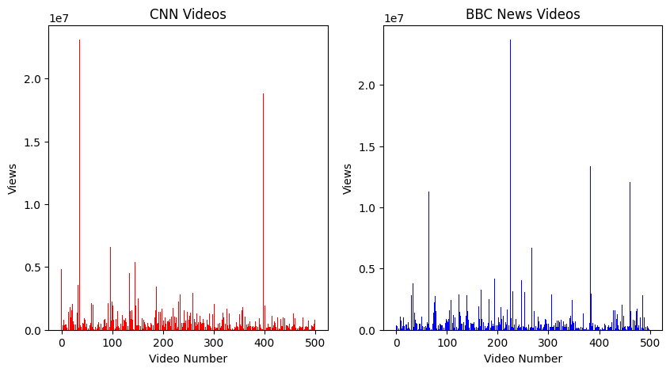

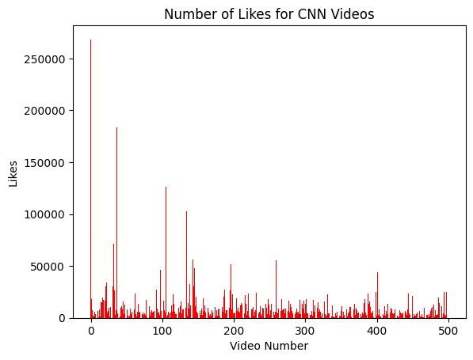

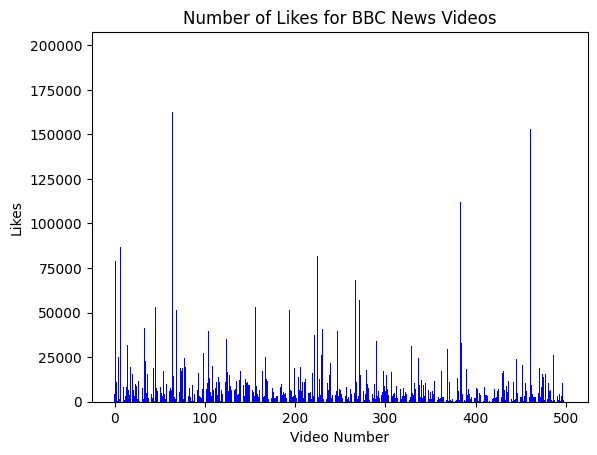

```python
# Creating a list of views for each channel (retrieved from: https://www.python-graph-gallery.com)
cnn_views = []
cnn_likes = []
bbc_views = []
bbc_likes = []

for index, row in cleaned_df.iterrows():
    views = int(row['views'])
    likes = int(row['likes'])
    if row['channel'] == 'CNN':
        cnn_views.append(views)
        cnn_likes.append(likes)
    elif row['channel'] == 'BBC News':
        bbc_views.append(views)
        bbc_likes.append(likes)

# Create two subplots
fig, (ax1, ax2) = plt.subplots(1, 2, figsize=(10, 5))

# Plot CNN views
ax1.bar(range(len(cnn_views)), cnn_views, color='red', label='CNN')
ax1.set_xlabel('Video Number')
ax1.set_ylabel('Views')
ax1.set_title('CNN Videos')

# Plot BBC News views
ax2.bar(range(len(bbc_views)), bbc_views, color='blue', label='BBC News')
ax2.set_xlabel('Video Number')
ax2.set_ylabel('Views')
ax2.set_title('BBC News Videos')
plt.show()

# Creating a bar plot of the likes for CNN
plt.bar(range(len(cnn_likes)), cnn_likes, color='red', label='CNN')
plt.xlabel('Video Number')
plt.ylabel('Likes')
plt.title('Number of Likes for CNN Videos')
plt.show()

# Create a bar plot of the likes for BBC News
plt.bar(range(len(bbc_likes)), bbc_likes, color='blue', label='BBC News')
plt.xlabel('Video Number')
plt.ylabel('Likes')
plt.title('Number of Likes for BBC News Videos')
plt.show()
```

In order to examine the number of likes and views of BBC News and CNN, the top 20 are filtered and portrayed in horizontal bar plots. This allows for comparisons to be made of the number of likes and views. For each row the number of likes and views is extracted from the 'likes' and 'views' columns and converted to an integer, and the video title is extracted.

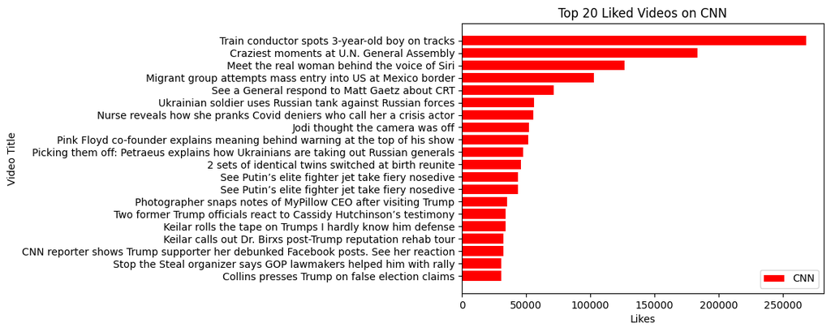

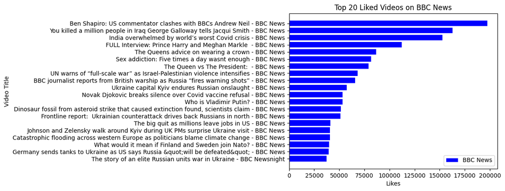

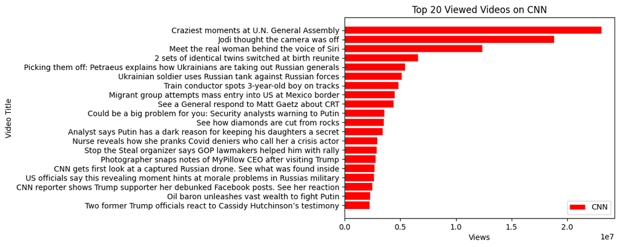

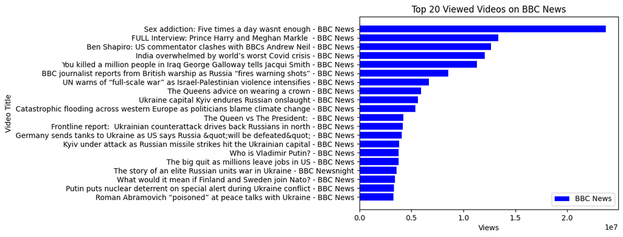

```python
# Filter and select the top 20 liked and viewed videos for CNN and BBC News
cnn_top_likes = cleaned_df[cleaned_df['channel'] == 'CNN'].nlargest(20, 'likes').sort_values('likes')
cnn_top_titles = cnn_top_likes['title']
cnn_top_views = cnn_top_likes['views']

cnn_top_views = cleaned_df[cleaned_df['channel'] == 'CNN'].nlargest(20, 'views').sort_values('views')
cnn_top_views_titles = cnn_top_views['title']
cnn_top_views_views = cnn_top_views['views']

bbc_top_likes = cleaned_df[cleaned_df['channel'] == 'BBC News'].nlargest(20, 'likes').sort_values('likes')
bbc_top_titles = bbc_top_likes['title']
bbc_top_views = bbc_top_likes['views']

bbc_top_views = cleaned_df[cleaned_df['channel'] == 'BBC News'].nlargest(20, 'views').sort_values('views')
bbc_top_views_titles = bbc_top_views['title']
bbc_top_views_views = bbc_top_views['views']

# Create a horizontal bar plot of the top 20 liked videos for CNN
plt.barh(range(len(cnn_top_likes)), cnn_top_likes['likes'], color='red', label='CNN')
plt.yticks(range(len(cnn_top_titles)), cnn_top_titles)
plt.xlabel('Likes')
plt.ylabel('Video Title')
plt.title('Top 20 Liked Videos on CNN')
plt.legend()
plt.show()

# Create a horizontal bar plot of the top 20 liked videos for BBC News
plt.barh(range(len(bbc_top_likes)), bbc_top_likes['likes'], color='blue', label='BBC News')
plt.yticks(range(len(bbc_top_titles)), bbc_top_titles)
plt.xlabel('Likes')
plt.ylabel('Video Title')
plt.title('Top 20 Liked Videos on BBC News')
plt.legend()
plt.show()

# Sort the dataframe by 'views' column in ascending order
cnn_top_views_sorted = cnn_top_views.sort_values(by='views')
bbc_top_views_sorted = bbc_top_views.sort_values(by='views')

# Create a horizontal bar plot of the top 20 viewed videos for CNN
plt.barh(range(len(cnn_top_views_sorted)), cnn_top_views_sorted['views'], color='red', label='CNN')
plt.yticks(range(len(cnn_top_views_titles)), cnn_top_views_titles)
plt.xlabel('Views')
plt.ylabel('Video Title')
plt.title('Top 20 Viewed Videos on CNN')
plt.legend()
plt.show()

# Create a horizontal bar plot of the top 20 viewed videos for BBC News
plt.barh(range(len(bbc_top_views_sorted)), bbc_top_views_sorted['views'], color='blue', label='BBC News')
plt.yticks(range(len(bbc_top_views_titles)), bbc_top_views_titles)
plt.xlabel('Views')
plt.ylabel('Video Title')
plt.title('Top 20 Viewed Videos on BBC News')
plt.legend()
plt.show()
```

The next exploratory examination concerns a word frequency analysis on the titles and descriptions of CNN and BBC News videos. It uses the Counter class from the collections module to count the occurrences of each word and retrieves the top 25 most mentioned words for each channel. It combines the cleaned titles and descriptions into separate strings, 'bbc_text' and 'cnn_text', by selecting the corresponding rows from the DataFrame.

To calculate the word frequencies, the text strings are split into individual words and passed to the Counter class, which counts the occurrences of each word. The top 25 most common words and their frequencies are stored in 'bbc_top_words' and 'cnn_top_words' variables for BBC News and CNN, respectively.

Finally, the code prints the top 25 words and their frequencies for each channel, providing insights into the most frequently used words in the cleaned titles and descriptions of BBC News and CNN.

```python
bbc_text = ' '.join(cleaned_df[cleaned_df['channel'] == 'BBC News']['title_cleaned'] + cleaned_df[cleaned_df['channel'] == 'BBC News']['description_cleaned'])
cnn_text = ' '.join(cleaned_df[cleaned_df['channel'] == 'CNN']['title_cleaned'] + cleaned_df[cleaned_df['channel'] == 'CNN']['description_cleaned'])

# Get word frequencies for BBC News
bbc_word_freq = Counter(bbc_text.split())
# Get the top 25 words and frequencies
bbc_top_words = bbc_word_freq.most_common(25)

# Get word frequencies for CNN
cnn_word_freq = Counter(cnn_text.split())
# Get the top 25 words and frequencies
cnn_top_words = cnn_word_freq.most_common(25)

# Print the top 25 words and frequencies for BBC News
print("Top 25 words in BBC News:")
for word, frequency in bbc_top_words:
    print(f"{word}: {frequency}")

# Print the top 25 words and frequencies for CNN
print("\nTop 25 words in CNN:")
for word, frequency in cnn_top_words:
    print(f"{word}: {frequency}")
```

```
Top 25 words in BBC News:
bbc: 503
ukraine: 161
russia: 109
russian: 95
uk: 91
president: 85
war: 71
says: 62
us: 50
ukrainian: 48
people: 48
putin: 46
coronavirus: 46
said: 44
city: 40
new: 39
country: 38
forces: 35
minister: 35
first: 35
invasion: 34
ukraines: 32
troops: 32
russias: 32
china: 30

Top 25 words in CNN:
trump: 145
former: 90
russian: 84
president: 81
donald: 57
trumps: 56
new: 55
us: 55
ukraine: 55
cnn: 53
house: 53
6: 50
says: 48
gop: 40
rep: 36
republican: 36
january: 35
white: 35
cnns: 33
video: 33
election: 32
see: 31
john: 30
ukrainian: 30
russia: 29
```

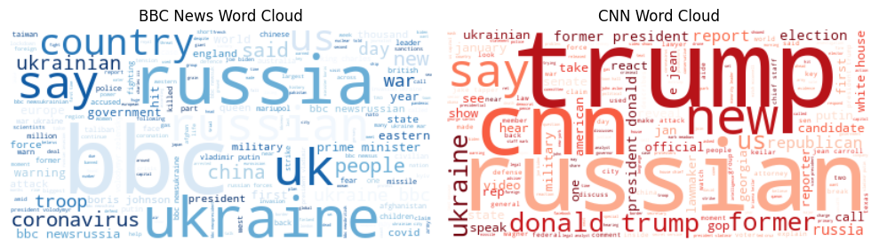

```python
bbc_wordcloud = WordCloud(background_color='white', colormap='Blues').generate(bbc_text)
cnn_wordcloud = WordCloud(background_color='white', colormap='Reds').generate(cnn_text)

# Plot the word clouds
plt.figure(figsize=(10, 5))  # Adjust the figure size as desired

plt.subplot(1, 2, 1)
plt.imshow(bbc_wordcloud, interpolation='bilinear')
plt.axis('off')
plt.title('BBC News Word Cloud')

plt.subplot(1, 2, 2)
plt.imshow(cnn_wordcloud, interpolation='bilinear')
plt.axis('off')
plt.title('CNN Word Cloud')

plt.tight_layout()
plt.show()
```

## 3. Sentiment Analysis

In order to answer the following research question:

RQ: To what extent can sentiment analysis be used to predict view count of news on YouTube?

This research shall evaluate 3 models:

Firstly, the sentiment form title is used as a categorical variable to predict view count as the dependant variable. Moreover, the 'sentiment_category_title' and 'sentiment_category_description' columns are one-hot encoded using the OneHotEncoder class from scikit-learn. This process converts the categorical data into a binary representation that can be used for modeling.The resulting encoded categories are stored in the 'categories_df' DataFrame. Next, the encoded categories are concatenated with the original DataFrame 'df' using pd.concat(), resulting in the 'df_encoded' DataFrame. This combines the original features with the encoded sentiment categories.

Finally, given the potentially more complex relationship between the variables as well as their types, this paper also uses a multiple regression model and tests it for accuracy, as this one might be more robust than the previous ones. In order to realize this, a linear regression model is trained using the LinearRegression() class from scikit-learn. The model is fitted on the training data using the fit() method. Based on the predict() method, predictions are made.

```python
# Sentiment predicting views based on sentiment title (Retrieved from: https://scikit-learn/stable/modules/generated/sklearn.preprocessing.OneHotEncoder.html)

# Perform one-hot encoding on the 'sentiment_category' column
one_hot_encoder = OneHotEncoder(sparse=False)
encoded_categories = one_hot_encoder.fit_transform(cleaned_df['sentiment_category_title'].values.reshape(-1, 1))
categories_df = pd.DataFrame(encoded_categories, columns=one_hot_encoder.categories_[0])

# Concatenate the encoded categories with the original DataFrame
df_encoded = pd.concat([df, categories_df], axis=1)

# Define the features (X) and target variable (y)
features = categories_df.columns.tolist()
target = 'views'

# Split the data into training and test sets
X_train, X_test, y_train, y_test = train_test_split(df_encoded[features], df_encoded[target], test_size=0.2, random_state=42)

# Train a linear regression model
model = LinearRegression()
model.fit(X_train, y_train)

# Make predictions on the test set
y_pred = model.predict(X_test)

# Evaluate the model
mse = mean_squared_error(y_test, y_pred)
r2 = r2_score(y_test, y_pred)

print(f"Mean Squared Error (MSE): {mse:.2f}")
print(f"R-squared (R2) Score: {r2:.2f}")
```

```
Mean Squared Error (MSE): 1439766912860.85
R-squared (R2) Score: -0.01
```

```python
# The same is done but then with description
# Perform one-hot encoding on the 'sentiment_category' column (Retrieved from:  https://scikit-learn/stable/modules/generated/sklearn.preprocessing.OneHotEncoder.html)
one_hot_encoder = OneHotEncoder(sparse=False)
encoded_categories = one_hot_encoder.fit_transform(cleaned_df['sentiment_category_description'].values.reshape(-1, 1))
categories_df = pd.DataFrame(encoded_categories, columns=one_hot_encoder.categories_[0])

# Concatenate the encoded categories with the original DataFrame
df_encoded = pd.concat([df, categories_df], axis=1)

# Define the features (X) and target variable (y)
features = categories_df.columns.tolist()
target = 'views'

# Split the data into training and test sets
X_train, X_test, y_train, y_test = train_test_split(df_encoded[features], df_encoded[target], test_size=0.2, random_state=42)

# Train a linear regression model
model = LinearRegression()
model.fit(X_train, y_train)

# Make predictions on the test set
y_pred = model.predict(X_test)

# Evaluate the model
mse = mean_squared_error(y_test, y_pred)
r2 = r2_score(y_test, y_pred)

print(f"Mean Squared Error (MSE): {mse:.2f}")
print(f"R-squared (R2) Score: {r2:.2f}")
```

```
Mean Squared Error (MSE): 1468847710290.61
R-squared (R2) Score: -0.03
```

```python
# Perform one-hot encoding on the 'sentiment_category' column (Retrieved from:  https://scikit-learn/stable/modules/generated/sklearn.preprocessing.OneHotEncoder.html)
one_hot_encoder = OneHotEncoder(sparse=False)
encoded_categories = one_hot_encoder.fit_transform(cleaned_df['sentiment_category_description'].values.reshape(-1, 1))
categories_df = pd.DataFrame(encoded_categories, columns=one_hot_encoder.categories_[0])

# Concatenate the encoded categories with the original DataFrame
df_encoded = pd.concat([df, categories_df], axis=1)

# Define the features (X) and target variable (y)
features = categories_df.columns.tolist() + ['Positive', 'Negative', 'Neutral']  # Add additional features here
target = 'views'

# Split the data into training and test sets
X_train, X_test, y_train, y_test = train_test_split(df_encoded[features], df_encoded[target], test_size=0.2, random_state=42)

# Train a linear regression model
model = LinearRegression()
model.fit(X_train, y_train)

# Make predictions on the test set
y_pred = model.predict(X_test)

# Evaluate the model
mse = mean_squared_error(y_test, y_pred)
r2 = r2_score(y_test, y_pred)

print(f"Mean Squared Error (MSE): {mse:.2f}")
print(f"R-squared (R2) Score: {r2:.2f}")
```

```
Mean Squared Error (MSE): 1463495343923.90
R-squared (R2) Score: -0.03
```

Despite the fact that the three models do not seem to support the notion that sentiment analysis can be used for predicting viewcounts on YouTube, a visual comparison is created of the distribution of sentiment categories between the two news channels.

It filters the DataFrame df to create two separate DataFrames, bbc_df and cnn_df, containing data only from the 'BBC News' and 'CNN' channels, respectively. Furthermore, the number of occurrences is counted of each sentiment category in the 'sentiment_category_description' and 'sentiment_category_title' column for the 'BBC News' and 'CNN' channels, storing the counts in cnn_sentiment_counts and bbc_sentiment_counts. In addition, the proportion of each sentiment category is calculated and divides the sentiment score by the sum of all counts.

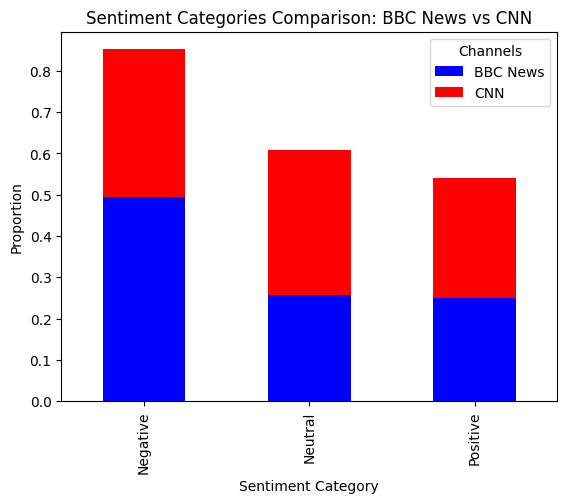

```python
# Filter the DataFrame for 'BBC News' and 'CNN' channels separately (Retrieved from: https://www.python-graph-gallery.com/)
bbc_df = cleaned_df[df['channel'] == 'BBC News']
cnn_df = cleaned_df[df['channel'] == 'CNN']

# Counting the number of each sentiment category for 'BBC News'
bbc_sentiment_counts = bbc_df['sentiment_category_description'].value_counts()

# Counting the number of each sentiment category for 'CNN'
cnn_sentiment_counts = cnn_df['sentiment_category_description'].value_counts()

# Calculate the proportion of each sentiment category for 'BBC News'
bbc_sentiment_proportions = bbc_sentiment_counts / bbc_sentiment_counts.sum()

# Calculate the proportion of each sentiment category for 'CNN'
cnn_sentiment_proportions = cnn_sentiment_counts / cnn_sentiment_counts.sum()

# Create a DataFrame for the proportions of sentiment categories
sentiment_df = pd.DataFrame({
    'BBC News': bbc_sentiment_proportions,
    'CNN': cnn_sentiment_proportions
})

# Plot the stacked bar plot
plt.figure(figsize=(8, 6))
sns.set_palette(['blue', 'red'])  # Set the colors for BBC News and CNN respectively
sentiment_df.plot(kind='bar', stacked=True)
plt.title('Sentiment Categories Comparison: BBC News vs CNN')
plt.xlabel('Sentiment Category')
plt.ylabel('Proportion')
plt.legend(title='Channels')
plt.show()
```

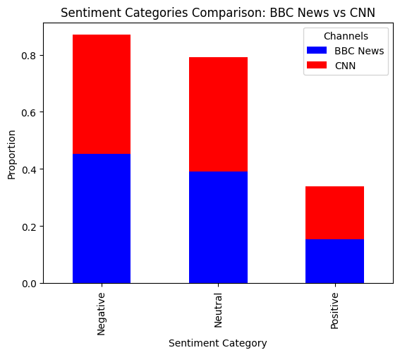

```python
# Filter the DataFrame for 'BBC News' and 'CNN' channels separately (Retrieved from: https://www.python-graph-gallery.com/)
bbc_df = cleaned_df[df['channel'] == 'BBC News']
cnn_df = cleaned_df[df['channel'] == 'CNN']

# Counting the number of each sentiment category for 'BBC News'
bbc_sentiment_counts = bbc_df['sentiment_category_title'].value_counts()

# Counting the number of each sentiment category for 'CNN'
cnn_sentiment_counts = cnn_df['sentiment_category_title'].value_counts()

# Calculate the proportion of each sentiment category for 'BBC News'
bbc_sentiment_proportions = bbc_sentiment_counts / bbc_sentiment_counts.sum()

# Calculate the proportion of each sentiment category for 'CNN'
cnn_sentiment_proportions = cnn_sentiment_counts / cnn_sentiment_counts.sum()

# Create a DataFrame for the proportions of sentiment categories
sentiment_df = pd.DataFrame({
    'BBC News': bbc_sentiment_proportions,
    'CNN': cnn_sentiment_proportions
})

# Plot the stacked bar plot
plt.figure(figsize=(8, 6))
sns.set_palette(['blue', 'red'])  # Set the colors for BBC News and CNN respectively
sentiment_df.plot(kind='bar', stacked=True)
plt.title('Sentiment Categories Comparison: BBC News vs CNN')
plt.xlabel('Sentiment Category')
plt.ylabel('Proportion')
plt.legend(title='Channels')
plt.show()
```

## References

Arcila, W. van A., Damian Trilling &. Carlos. (2022, March 11). Computational Analysis of Communication. https://cssbook.net/

Holtz, Y. (n.d.). The Python Graph Gallery. Retrieved May 3, 2023, from https://www.python-graph-gallery.com/

Sklearn.preprocessing.OneHotEncoder. (n.d.). Scikit-Learn. Retrieved May 13, 2023, from https://scikit-learn/stable/modules/generated/sklearn.preprocessing.OneHotEncoder.html

YouTube Data API. (n.d.). Google Developers. Retrieved April 24, 2023, from https://developers.google.com/youtube/v3